# **Data Visualization Lab**

Estimated time needed: **45 to 60** minutes

In this assignment you will be focusing on the visualization of data.

The data set will be presented to you in the form of a RDBMS.

You will have to use SQL queries to extract the data.

## Objectives

In this lab you will perform the following:

- Visualize the distribution of data.
- Visualize the relationship between two features.
- Visualize composition of data.
- Visualize comparison of data.

## Demo: How to work with database

Download database file.

```python
!wget https://cf-courses-data.s3.us.cloud-object-storage.appdomain.cloud/IBM-DA0321EN-SkillsNetwork/LargeData/m4_survey_data.sqlite
```

```
--2024-02-19 05:55:30--  https://cf-courses-data.s3.us.cloud-object-storage.appdomain.cloud/IBM-DA0321EN-SkillsNetwork/LargeData/m4_survey_data.sqlite
Resolving cf-courses-data.s3.us.cloud-object-storage.appdomain.cloud (cf-courses-data.s3.us.cloud-object-storage.appdomain.cloud)... 169.63.118.104, 169.63.118.104
Connecting to cf-courses-data.s3.us.cloud-object-storage.appdomain.cloud (cf-courses-data.s3.us.cloud-object-storage.appdomain.cloud)|169.63.118.104|:443... connected.
HTTP request sent, awaiting response... 200 OK
Length: 36679680 (35M) [application/octet-stream]
Saving to: ‘m4_survey_data.sqlite’

m4_survey_data.sqli 100%[===================>]  34.98M  41.4MB/s    in 0.8s

2024-02-19 05:55:32 (41.4 MB/s) - ‘m4_survey_data.sqlite’ saved [36679680/36679680]
```

Connect to the database.

```python
import sqlite3
conn = sqlite3.connect("m4_survey_data.sqlite") # open a database connection
```

Import pandas module.

```python
import pandas as pd
import matplotlib.pyplot as plt
%matplotlib inline
```

## Demo: How to run an sql query

```python
# print how many rows are there in the table named 'master'
QUERY = """
SELECT COUNT(*)
FROM master
"""

# the read_sql_query runs the sql query and returns the data as a dataframe
df = pd.read_sql_query(QUERY,conn)
df.head()
```

|  | COUNT(*) |
| --- | --- |
| 0 | 11398 |

## Demo: How to list all tables

```python
# print all the tables names in the database
QUERY = """
SELECT name as Table_Name FROM
sqlite_master WHERE
type = 'table'
"""
# the read_sql_query runs the sql query and returns the data as a dataframe
pd.read_sql_query(QUERY,conn)
```

|  | Table_Name |
| --- | --- |
| 0 | EduOther |
| 1 | DevType |
| 2 | LastInt |
| 3 | JobFactors |
| 4 | WorkPlan |
| 5 | WorkChallenge |
| 6 | LanguageWorkedWith |
| 7 | LanguageDesireNextYear |
| 8 | DatabaseWorkedWith |
| 9 | DatabaseDesireNextYear |
| 10 | PlatformWorkedWith |
| 11 | PlatformDesireNextYear |
| 12 | WebFrameWorkedWith |
| 13 | WebFrameDesireNextYear |
| 14 | MiscTechWorkedWith |
| 15 | MiscTechDesireNextYear |
| 16 | DevEnviron |
| 17 | Containers |
| 18 | SOVisitTo |
| 19 | SONewContent |
| 20 | Gender |
| 21 | Sexuality |
| 22 | Ethnicity |
| 23 | master |

## Demo: How to run a group by query

```python
QUERY = """
SELECT Age,COUNT(*) as count
FROM master
group by age
order by age
"""
pd.read_sql_query(QUERY,conn)
```

|  | Age | count |
| --- | --- | --- |
| 0 | NaN | 287 |
| 1 | 16.0 | 3 |
| 2 | 17.0 | 6 |
| 3 | 18.0 | 29 |
| 4 | 19.0 | 78 |
| 5 | 20.0 | 109 |
| 6 | 21.0 | 203 |
| 7 | 22.0 | 406 |
| 8 | 23.0 | 581 |
| 9 | 24.0 | 679 |
| 10 | 25.0 | 738 |
| 11 | 26.0 | 720 |
| 12 | 27.0 | 724 |
| 13 | 28.0 | 787 |
| 14 | 29.0 | 697 |
| 15 | 30.0 | 651 |
| 16 | 31.0 | 531 |
| 17 | 32.0 | 489 |
| 18 | 33.0 | 483 |
| 19 | 34.0 | 395 |
| 20 | 35.0 | 393 |
| 21 | 36.0 | 308 |
| 22 | 37.0 | 280 |
| 23 | 38.0 | 279 |
| 24 | 39.0 | 232 |
| 25 | 40.0 | 187 |
| 26 | 41.0 | 136 |
| 27 | 42.0 | 162 |
| 28 | 43.0 | 100 |
| 29 | 44.0 | 95 |
| 30 | 45.0 | 85 |
| 31 | 46.0 | 66 |
| 32 | 47.0 | 68 |
| 33 | 48.0 | 64 |
| 34 | 49.0 | 66 |
| 35 | 50.0 | 57 |
| 36 | 51.0 | 29 |
| 37 | 52.0 | 41 |
| 38 | 53.0 | 32 |
| 39 | 54.0 | 26 |
| 40 | 55.0 | 13 |
| 41 | 56.0 | 16 |
| 42 | 57.0 | 11 |
| 43 | 58.0 | 12 |
| 44 | 59.0 | 11 |
| 45 | 60.0 | 2 |
| 46 | 61.0 | 10 |
| 47 | 62.0 | 5 |
| 48 | 63.0 | 7 |
| 49 | 65.0 | 2 |
| 50 | 66.0 | 1 |
| 51 | 67.0 | 1 |
| 52 | 69.0 | 1 |
| 53 | 71.0 | 2 |
| 54 | 72.0 | 1 |
| 55 | 99.0 | 1 |

## Demo: How to describe a table

```python
table_name = 'master'  # the table you wish to describe

QUERY = """
SELECT sql FROM sqlite_master
WHERE name= '{}'
""".format(table_name)

df = pd.read_sql_query(QUERY,conn)
print(df.iat[0,0])
```

```
CREATE TABLE "master" (
"index" INTEGER,
  "Respondent" INTEGER,
  "MainBranch" TEXT,
  "Hobbyist" TEXT,
  "OpenSourcer" TEXT,
  "OpenSource" TEXT,
  "Employment" TEXT,
  "Country" TEXT,
  "Student" TEXT,
  "EdLevel" TEXT,
  "UndergradMajor" TEXT,
  "OrgSize" TEXT,
  "YearsCode" TEXT,
  "Age1stCode" TEXT,
  "YearsCodePro" TEXT,
  "CareerSat" TEXT,
  "JobSat" TEXT,
  "MgrIdiot" TEXT,
  "MgrMoney" TEXT,
  "MgrWant" TEXT,
  "JobSeek" TEXT,
  "LastHireDate" TEXT,
  "FizzBuzz" TEXT,
  "ResumeUpdate" TEXT,
  "CurrencySymbol" TEXT,
  "CurrencyDesc" TEXT,
  "CompTotal" REAL,
  "CompFreq" TEXT,
  "ConvertedComp" REAL,
  "WorkWeekHrs" REAL,
  "WorkRemote" TEXT,
  "WorkLoc" TEXT,
  "ImpSyn" TEXT,
  "CodeRev" TEXT,
  "CodeRevHrs" REAL,
  "UnitTests" TEXT,
  "PurchaseHow" TEXT,
  "PurchaseWhat" TEXT,
  "OpSys" TEXT,
```

[output cut: 10 more lines]

```
  "SOFindAnswer" TEXT,
  "SOTimeSaved" TEXT,
  "SOHowMuchTime" TEXT,
  "SOAccount" TEXT,
  "SOPartFreq" TEXT,
  "SOJobs" TEXT,
  "EntTeams" TEXT,
  "SOComm" TEXT,
  "WelcomeChange" TEXT,
  "Age" REAL,
  "Trans" TEXT,
  "Dependents" TEXT,
  "SurveyLength" TEXT,
  "SurveyEase" TEXT
)
```

# Hands-on Lab

## Visualizing distribution of data

### Histograms

Plot a histogram of `ConvertedComp.`

```python
import numpy as np
import matplotlib.pyplot as plt
plt.figure(figsize=(10, 6))
plt.hist(ConvertedComp)#(df["ConvertedComp"], bins=20, color='skyblue', edgecolor='black')
plt.title("Histogram of ConvertedComp")
plt.xlabel("Converted Compensation")
plt.ylabel("Frequency")
plt.show()
```

[output not shown]

[figure not shown]

```python
import numpy as np
import matplotlib.pyplot as plt

# Sample data (replace with your actual data)
converted_comp = np.random.randn(1000)  # Assuming ConvertedComp is a numerical variable

# Create the histogram
plt.hist(converted_comp)
plt.xlabel("ConvertedComp")
plt.ylabel("Frequency")
plt.title("Histogram of ConvertedComp")
plt.show()
```

### Box Plots

Plot a box plot of `Age.`

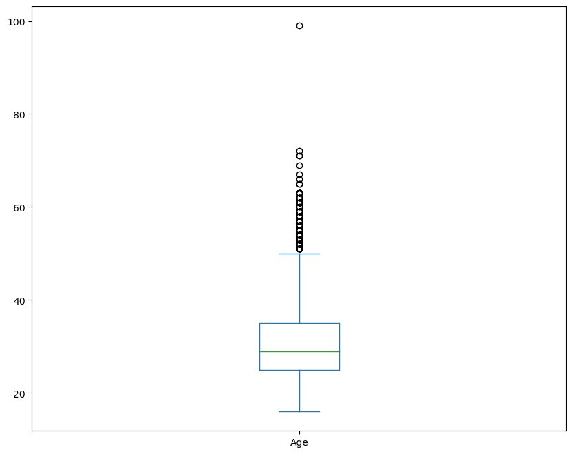

```python
Query2 = """
SELECT Age
FROM master
"""

Age= pd.read_sql_query(Query2, conn)
Age.plot(kind='box', figsize=(10, 8))
```

## Visualizing relationships in data

### Scatter Plots

Create a scatter plot of `Age` and `WorkWeekHrs.`

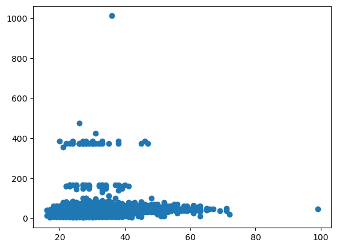

```python
Query3= """
SELECT Age
FROM master
"""
Query4= """
SELECT WorkWeekHrs
FROM master
"""

Query5="""
SELECT Age, WorkWeekHrs
FROM master
"""
Age=pd.read_sql_query(Query3, conn)
WorkWeekHrs= pd.read_sql_query(Query4, conn)
Age_WorkWeekHrs=pd.read_sql_query(Query5, conn)
plt.scatter(x=Age, y=WorkWeekHrs)
```

### Bubble Plots

Create a bubble plot of `WorkWeekHrs` and `CodeRevHrs`, use `Age` column as bubble size.

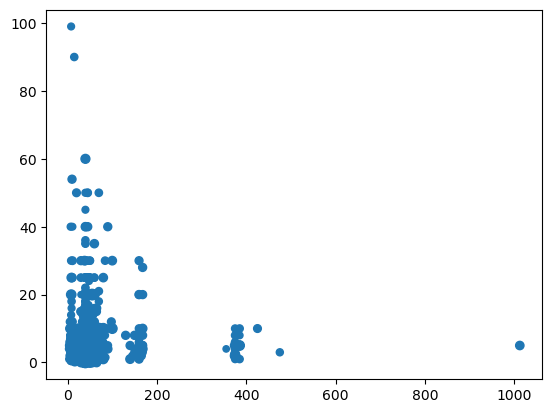

```python
Query6 = """
SELECT CodeRevHrs
FROM master
"""
CodeRevHrs=pd.read_sql_query(Query6, conn)
plt.scatter(x=WorkWeekHrs, y=CodeRevHrs, s=Age)
```

## Visualizing composition of data

### Pie Charts

Create a pie chart of the top 5 databases that respondents wish to learn next year. Label the pie chart with database names. Display percentages of each database on the pie chart.

[output not shown]

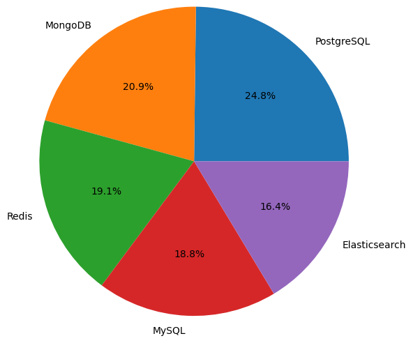

```python
Query7="""
SELECT DatabaseDesireNextYear, count(*) as count
FROM DatabaseDesireNextYear
group by DatabaseDesireNextYear
order by count desc limit 5
"""

DatabaseDesireNextYear= pd.read_sql_query(Query7, conn)
x = DatabaseDesireNextYear['count']
label = DatabaseDesireNextYear['DatabaseDesireNextYear']
plt.pie(x, labels=label, autopct='%1.1f%%',radius=1.5)
```

### Stacked Charts

```
<BarContainer object of 6 artists>
```

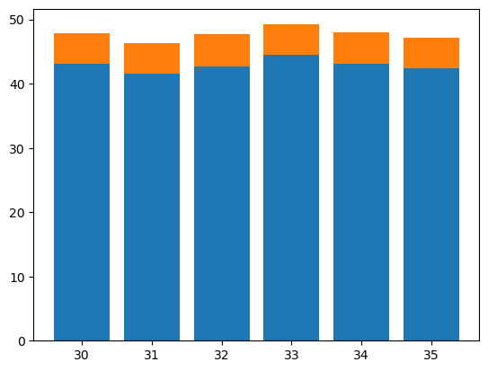

```python
Query8 = """
SELECT Avg(WorkWeekHrs), Avg(CodeRevHrs), Age
FROM master
where Age between 30 and 35
group by Age
"""
z = pd.read_sql_query(Query8, conn)
WorkWeekHrs= z['Avg(WorkWeekHrs)']
CodeRevHrs= z['Avg(CodeRevHrs)']
Age= z['Age']

fig, ax = plt.subplots()

ax.bar(Age, WorkWeekHrs, label='WorkWeekHrs')
ax.bar(Age, CodeRevHrs, bottom=WorkWeekHrs,
       label='CodeRevHrs')
```

## Visualizing comparison of data

### Line Chart

```
    Avg(ConvertedComp)   Age
0        187374.012821  45.0
1        231703.737705  46.0
2        142093.126984  47.0
3        157251.532258  48.0
4        214709.000000  49.0
5        143120.464286  50.0
6        123404.666667  51.0
7        255217.236842  52.0
8        257196.758621  53.0
9        144287.041667  54.0
10       150508.583333  55.0
11       107843.357143  56.0
12       127548.700000  57.0
13       332839.833333  58.0
14       350231.800000  59.0
15       132287.500000  60.0
```

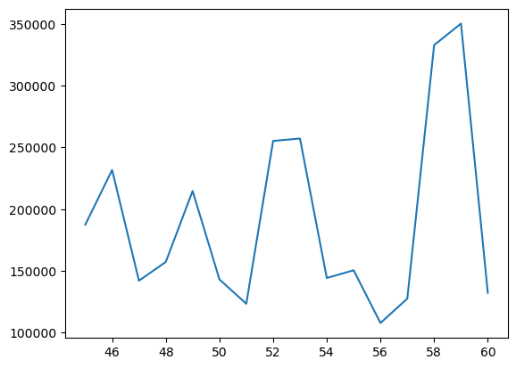

```python
Query9= """
SELECT Avg(ConvertedComp), Age
FROM master
where age between 45 and 60
group by Age
"""

ConvertedComp_Age= pd.read_sql_query(Query9, conn)
ConvertedComp_Age
plt.plot(ConvertedComp_Age['Age'],ConvertedComp_Age['Avg(ConvertedComp)'])
print(ConvertedComp_Age)
```

### Bar Chart

Create a horizontal bar chart using column `MainBranch.`

|  | MainBranch | count(*) |
| --- | --- | --- |
| 0 | I am a developer by profession | 10618 |
| 1 | I am not primarily a developer, but I write co... | 780 |

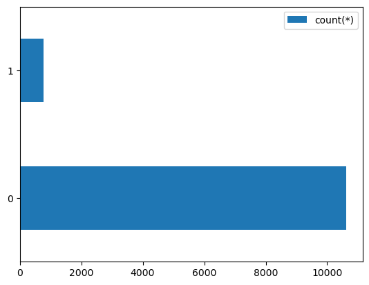

```python
Query10="""
SELECT MainBranch, count(*)
FROM master
group by MainBranch
"""
MainBranch=pd.read_sql_query(Query10, conn)
MainBranch.plot(kind='barh')
MainBranch
```

Close the database connection.

```python
conn.close()
```

## Authors

Ramesh Sannareddy

### Other Contributors

Rav Ahuja

## Change Log

| Date (YYYY-MM-DD) | Version | Changed By | Change Description |
| --- | --- | --- | --- |
| 2020-10-17 | 0.1 | Ramesh Sannareddy | Created initial version of the lab |

Copyright © 2020 IBM Corporation. This notebook and its source code are released under the terms of the MIT License.